# INN Hotels Project

## Context

A significant number of hotel bookings are called-off due to cancellations or no-shows. The typical reasons for cancellations include change of plans, scheduling conflicts, etc. This is often made easier by the option to do so free of charge or preferably at a low cost which is beneficial to hotel guests but it is a less desirable and possibly revenue-diminishing factor for hotels to deal with. Such losses are particularly high on last-minute cancellations.

The new technologies involving online booking channels have dramatically changed customers’ booking possibilities and behavior. This adds a further dimension to the challenge of how hotels handle cancellations, which are no longer limited to traditional booking and guest characteristics.

The cancellation of bookings impact a hotel on various fronts:

- Loss of resources (revenue) when the hotel cannot resell the room.
- Additional costs of distribution channels by increasing commissions or paying for publicity to help sell these rooms.
- Lowering prices last minute, so the hotel can resell a room, resulting in reducing the profit margin.
- Human resources to make arrangements for the guests.

## Objective

The increasing number of cancellations calls for a Machine Learning based solution that can help in predicting which booking is likely to be canceled. INN Hotels Group has a chain of hotels in Portugal, they are facing problems with the high number of booking cancellations and have reached out to your firm for data-driven solutions. You as a data scientist have to analyze the data provided to find which factors have a high influence on booking cancellations, build a predictive model that can predict which booking is going to be canceled in advance, and help in formulating profitable policies for cancellations and refunds.

## Data Description

The data contains the different attributes of customers' booking details. The detailed data dictionary is given below.

**Data Dictionary**

- Booking_ID: unique identifier of each booking
- no_of_adults: Number of adults
- no_of_children: Number of Children
- no_of_weekend_nights: Number of weekend nights (Saturday or Sunday) the guest stayed or booked to stay at the hotel
- no_of_week_nights: Number of week nights (Monday to Friday) the guest stayed or booked to stay at the hotel
- type_of_meal_plan: Type of meal plan booked by the customer:
  - Not Selected – No meal plan selected
  - Meal Plan 1 – Breakfast
  - Meal Plan 2 – Half board (breakfast and one other meal)
  - Meal Plan 3 – Full board (breakfast, lunch, and dinner)
- required_car_parking_space: Does the customer require a car parking space? (0 - No, 1- Yes)
- room_type_reserved: Type of room reserved by the customer. The values are ciphered (encoded) by INN Hotels.
- lead_time: Number of days between the date of booking and the arrival date
- arrival_year: Year of arrival date
- arrival_month: Month of arrival date
- arrival_date: Date of the month
- market_segment_type: Market segment designation.
- repeated_guest: Is the customer a repeated guest? (0 - No, 1- Yes)
- no_of_previous_cancellations: Number of previous bookings that were canceled by the customer prior to the current booking
- no_of_previous_bookings_not_canceled: Number of previous bookings not canceled by the customer prior to the current booking
- avg_price_per_room: Average price per day of the reservation; prices of the rooms are dynamic. (in euros)
- no_of_special_requests: Total number of special requests made by the customer (e.g. high floor, view from the room, etc)
- booking_status: Flag indicating if the booking was canceled or not.

## Importing necessary libraries and data

```python
# this will help in making the Python code more structured automatically (good coding practice)
#%load_ext nb_black

import warnings

warnings.filterwarnings("ignore")
from statsmodels.tools.sm_exceptions import ConvergenceWarning

warnings.simplefilter("ignore", ConvergenceWarning)

# Libraries to help with reading and manipulating data

import pandas as pd
import numpy as np

# Library to split data
from sklearn.model_selection import train_test_split

# libaries to help with data visualization
import matplotlib.pyplot as plt
import seaborn as sns

# Removes the limit for the number of displayed columns
pd.set_option("display.max_columns", None)
# Sets the limit for the number of displayed rows
pd.set_option("display.max_rows", 200)


# To build model for prediction
import statsmodels.stats.api as sms
from statsmodels.stats.outliers_influence import variance_inflation_factor
import statsmodels.api as sm
from statsmodels.tools.tools import add_constant
from sklearn.linear_model import LogisticRegression
# To build model for prediction
from sklearn.tree import DecisionTreeClassifier
from sklearn import tree

# To tune different models
from sklearn.model_selection import GridSearchCV

# To get diferent metric scores
from sklearn.metrics import (
    f1_score,
    accuracy_score,
    recall_score,
    precision_score,
    confusion_matrix,
    roc_auc_score,
    ConfusionMatrixDisplay,
    precision_recall_curve,
    roc_curve,
    make_scorer
)
```

```python
from google.colab import drive
drive.mount('/content/drive')
```

```python
df = pd.read_csv("/content/drive/MyDrive/INNHotelsGroup.csv")
```

## Data Overview

- Observations
- Sanity checks

```python
df.info()
```

```
<class 'pandas.core.frame.DataFrame'>
RangeIndex: 36275 entries, 0 to 36274
Data columns (total 19 columns):
 #   Column                                Non-Null Count  Dtype
---  ------                                --------------  -----
 0   Booking_ID                            36275 non-null  object
 1   no_of_adults                          36275 non-null  int64
 2   no_of_children                        36275 non-null  int64
 3   no_of_weekend_nights                  36275 non-null  int64
 4   no_of_week_nights                     36275 non-null  int64
 5   type_of_meal_plan                     36275 non-null  object
 6   required_car_parking_space            36275 non-null  int64
 7   room_type_reserved                    36275 non-null  object
 8   lead_time                             36275 non-null  int64
 9   arrival_year                          36275 non-null  int64
 10  arrival_month                         36275 non-null  int64
 11  arrival_date                          36275 non-null  int64
 12  market_segment_type                   36275 non-null  object
 13  repeated_guest                        36275 non-null  int64
 14  no_of_previous_cancellations          36275 non-null  int64
 15  no_of_previous_bookings_not_canceled  36275 non-null  int64
 16  avg_price_per_room                    36275 non-null  float64
 17  no_of_special_requests                36275 non-null  int64
 18  booking_status                        36275 non-null  object
dtypes: float64(1), int64(13), object(5)
memory usage: 5.3+ MB
```

## Exploratory Data Analysis (EDA)

- EDA is an important part of any project involving data.
- It is important to investigate and understand the data better before building a model with it.
- A few questions have been mentioned below which will help you approach the analysis in the right manner and generate insights from the data.
- A thorough analysis of the data, in addition to the questions mentioned below, should be done.

**Leading Questions**:

1. What are the busiest months in the hotel?
2. Which market segment do most of the guests come from?
3. Hotel rates are dynamic and change according to demand and customer demographics. What are the differences in room prices in different market segments?
4. What percentage of bookings are canceled?
5. Repeating guests are the guests who stay in the hotel often and are important to brand equity. What percentage of repeating guests cancel?
6. Many guests have special requirements when booking a hotel room. Do these requirements affect booking cancellation?

### Question 1: What are the busiest months in the hotel?

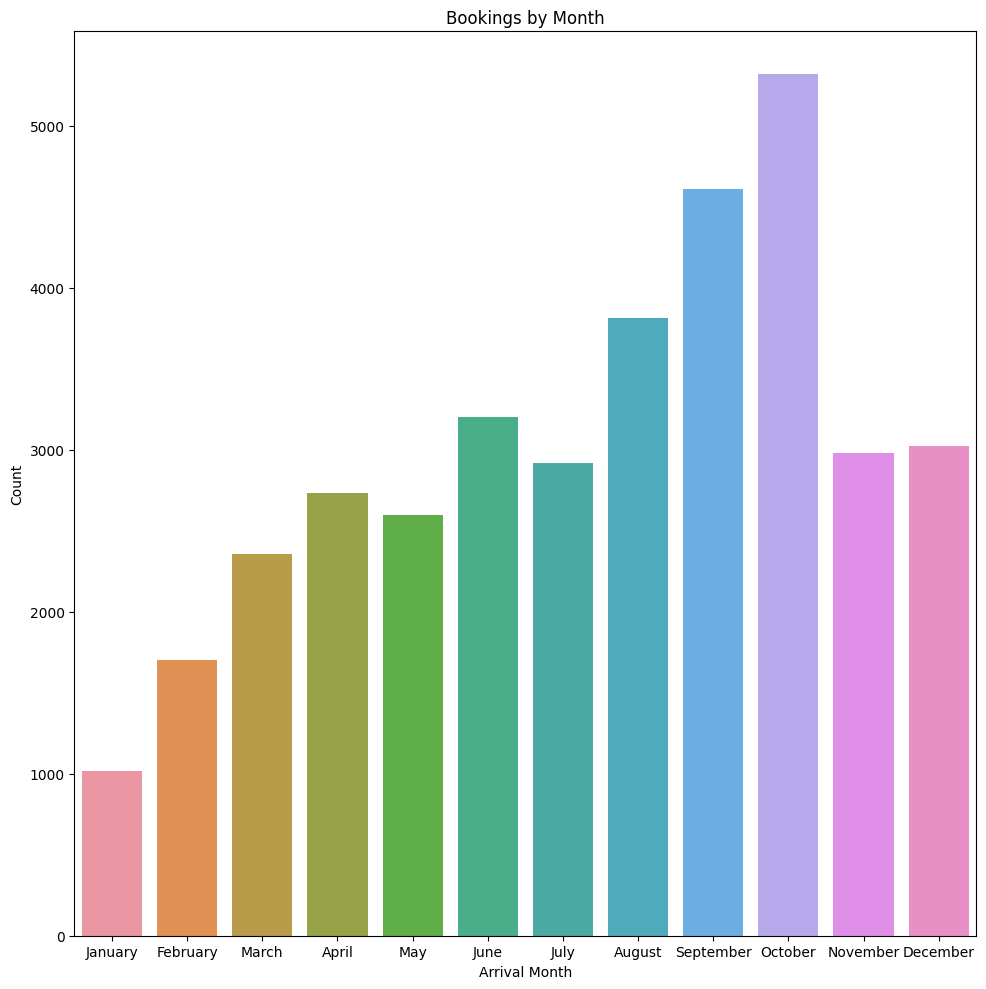

```python
fig, monthCountplot = plt.subplots()
monthCountplot = sns.countplot(data = df, x= "arrival_month")
monthCountplot.set_xlabel("Arrival Month")
monthCountplot.set_ylabel("Count")
monthCountplot.set_title("Bookings by Month")
monthCountplot.set_xticks(range(len(df["arrival_month"].unique())))
monthCountplot.set_xticklabels(["January", "February", "March", "April", "May", "June", "July", "August", "September", "October", "November", "December"])
fig.set_size_inches(10,10)
fig.tight_layout()
```

### Question 2: Which Market Segment do most of the guests come from?

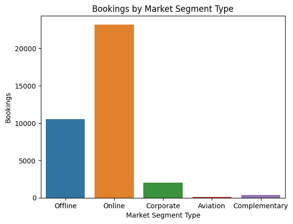

```python
sns.countplot(data = df, x= "market_segment_type")
plt.xlabel("Market Segment Type")
plt.ylabel("Bookings")
plt.title("Bookings by Market Segment Type")
plt.show()
```

Per the bar graph shown above, the market segment that has the most bookings is the online market.

### Question 3: Hotel rates are dynamic and change according to demand and customer demographics. What are the differences in room prices in different market segments?

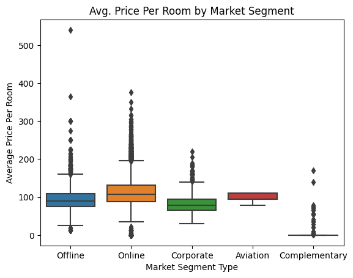

```python
sns.boxplot(data = df, x = "market_segment_type", y = "avg_price_per_room")
plt.xlabel("Market Segment Type")
plt.ylabel("Average Price Per Room")
plt.title("Avg. Price Per Room by Market Segment")
plt.show()
```

The measures of centrality regarding price per room do not vary much between the market segment type, except for the complementary category, which is expected.

### Question 4: What percentage of bookings are canceled?

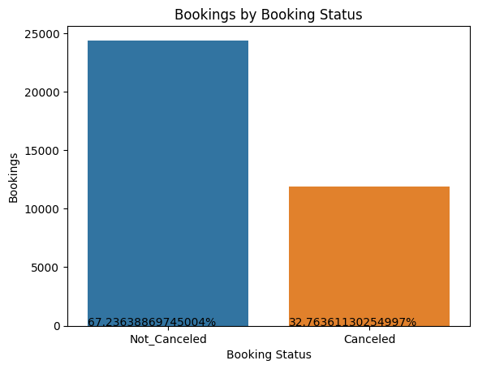

```python
ax = sns.countplot(data = df, x= "booking_status")
plt.xlabel("Booking Status")
plt.ylabel("Bookings")
plt.title("Bookings by Booking Status")
for p in ax.patches:
  perc = str((100 * p.get_height())/len(df["booking_status"])) + "%"
  ax.annotate(perc, (p.get_x(), p.get_y()))
plt.show()
```

### Question 5: Repeating guests are the guests who stay in the hotel often and are important to brand equity. What percentage of repeating guests cancel?

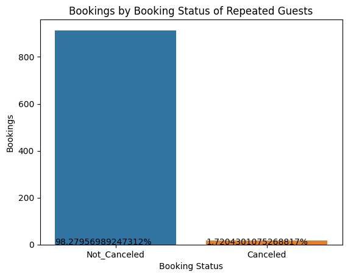

```python
new_df = df.loc[df["repeated_guest"] == 1]
ax = sns.countplot(data = new_df, x= "booking_status")
plt.xlabel("Booking Status")
plt.ylabel("Bookings")
plt.title("Bookings by Booking Status of Repeated Guests")
for p in ax.patches:
  perc = str((100 * p.get_height())/len(new_df["booking_status"])) + "%"
  ax.annotate(perc, (p.get_x(), p.get_y()))
plt.show()
```

Only 1.72% of repeated guests canceled.

### Question 6: Many guests have special requirements when booking a hotel room. Do these requirements affect booking cancellation?

```python
def proportion_countplot(dataframe, feature):
  sns.countplot(data = dataframe, x= feature, hue = "booking_status")
  percCancelledWithin = {}
  percCancelledWithin = pd.DataFrame(percCancelledWithin)
  for i in df[feature].unique():
    new_df = df.loc[df[feature] == i]
    numCancelled = 0
    for p in new_df["booking_status"]:
      if p == 'Canceled':
        numCancelled += 1
    percCancelled = (numCancelled/len(new_df["booking_status"])) * 100
    percCancelled = [percCancelled]
    percCancelledWithin[i] = percCancelled
    #print(percCancelled)

  percCancelledWithin.index = ["Percentage Cancelled within Category"]
  return percCancelledWithin
```

|  | 0 | 1 | 3 | 2 | 4 | 5 |
| --- | --- | --- | --- | --- | --- | --- |
| Percentage Cancelled within Category | 43.206755 | 23.766816 | 0.0 | 14.5967 | 0.0 | 0.0 |

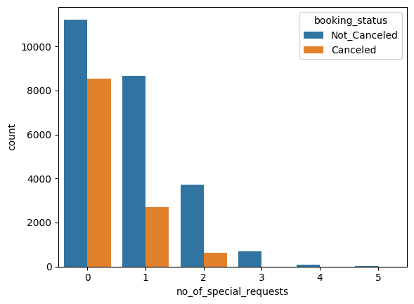

```python
proportion_countplot(df, "no_of_special_requests")
```

It seems that the proportion of canceled vs uncanceled bookings tend to decrease when the number of special requests go up.

|  | Meal Plan 1 | Not Selected | Meal Plan 2 | Meal Plan 3 |
| --- | --- | --- | --- | --- |
| Percentage Cancelled within Category | 31.180169 | 33.118908 | 45.567322 | 20.0 |

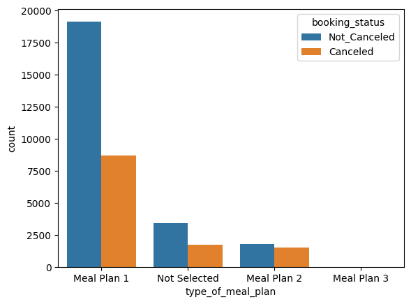

```python
proportion_countplot(df, "type_of_meal_plan")
```

Similarly, we can do this with other categorical variables. Guests that chose meal plan 2 have the highest proportion of canceled bookings with nearly half of the category having canceled bookings, followed by guests with no selection and meal plan 1 with about a third of each category having canceled bookings. Finally, meal plan 3 only has about a fifth of the category having canceled bookings.

|  | 0 | 1 |
| --- | --- | --- |
| Percentage Cancelled within Category | 33.486956 | 10.142349 |

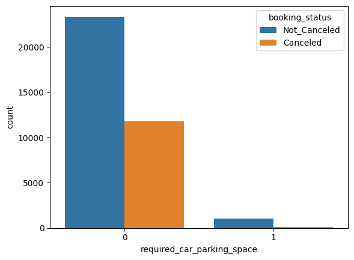

```python
proportion_countplot(df, "required_car_parking_space")
```

There is a higher proportion of cancellations for those that don't require a parking space.

|  | Room_Type 1 | Room_Type 4 | Room_Type 2 | Room_Type 6 | Room_Type 5 | Room_Type 7 | Room_Type 3 |
| --- | --- | --- | --- | --- | --- | --- | --- |
| Percentage Cancelled within Category | 32.250267 | 34.158825 | 32.947977 | 42.028986 | 27.169811 | 22.78481 | 28.571429 |

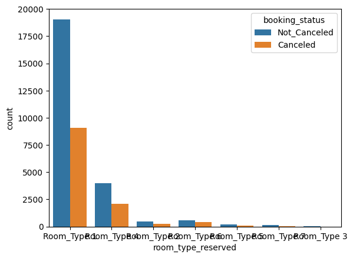

```python
proportion_countplot(df, "room_type_reserved")
```

|  | Offline | Online | Corporate | Aviation | Complementary |
| --- | --- | --- | --- | --- | --- |
| Percentage Cancelled within Category | 29.948708 | 36.508142 | 10.907288 | 29.6 | 0.0 |

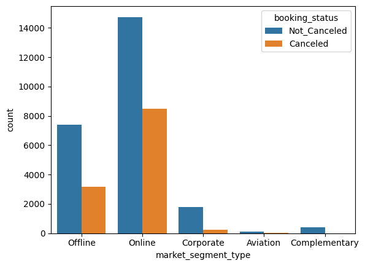

```python
proportion_countplot(df, "market_segment_type")
```

Online guests showed the highest proportion of cancellations versus any other market segment.

|  | 0 | 3 | 1 | 2 | 11 | 4 | 5 | 13 | 6 |
| --- | --- | --- | --- | --- | --- | --- | --- | --- | --- |
| Percentage Cancelled within Category | 33.027242 | 2.325581 | 5.555556 | 0.0 | 0.0 | 0.0 | 0.0 | 100.0 | 0.0 |

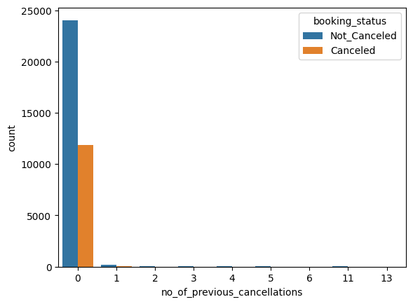

```python
proportion_countplot(df, "no_of_previous_cancellations")
```

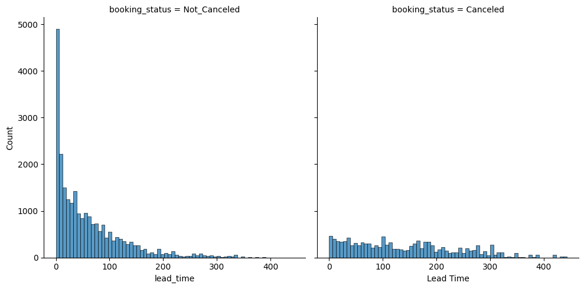

```python
sns.displot(data = df, x = "lead_time", col = "booking_status")
plt.xlabel("Lead Time")
plt.show()
```

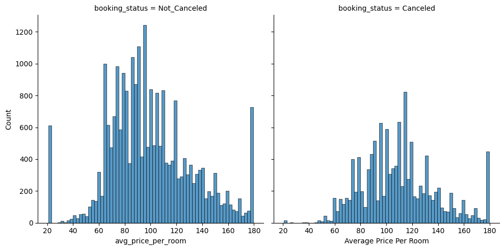

```python
sns.displot(data = df, x = "avg_price_per_room", col = "booking_status")
plt.xlabel("Average Price Per Room")
plt.show()
```

## Data Preprocessing

- Missing value treatment (if needed)
- Feature engineering (if needed)
- Outlier detection and treatment (if needed)
- Preparing data for modeling
- Any other preprocessing steps (if needed)

```python
df.drop(["Booking_ID"], axis = 1, inplace = True)
df.drop(["arrival_date"], axis = 1, inplace = True)
df.drop(["arrival_month"], axis = 1, inplace = True)
df.drop(["arrival_year"], axis = 1, inplace = True)
```

There are no missing values in any of the columns so we need to see if we have any outliers within the columns that are numeric.

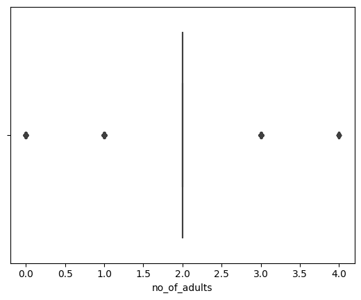

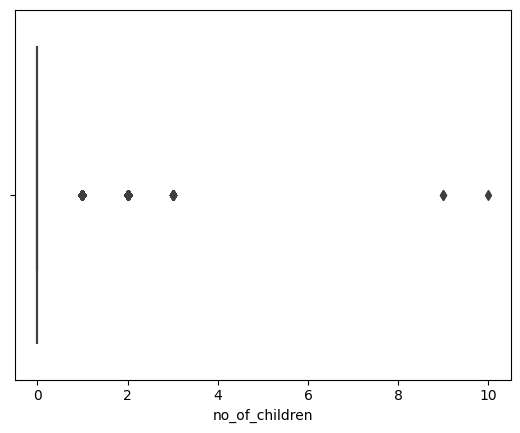

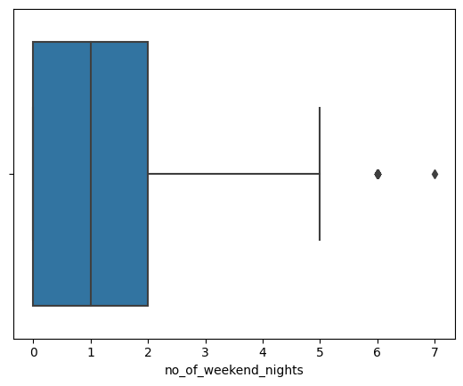

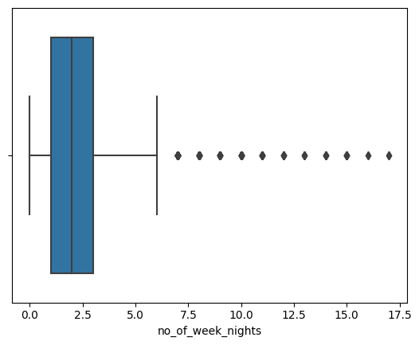

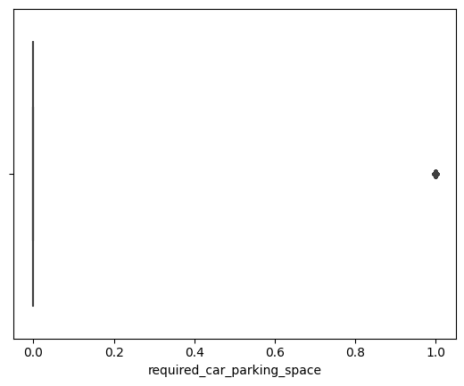

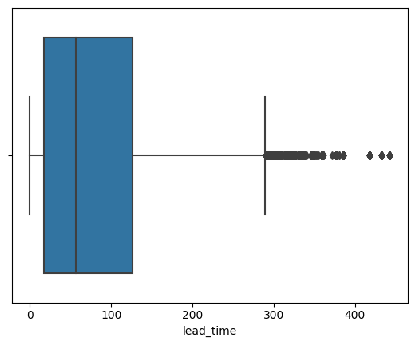

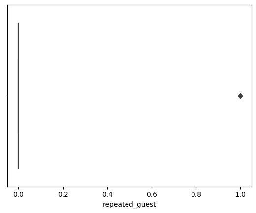

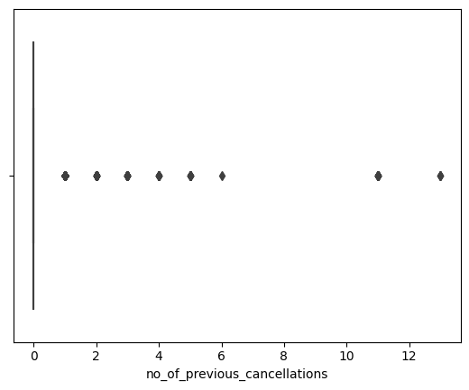

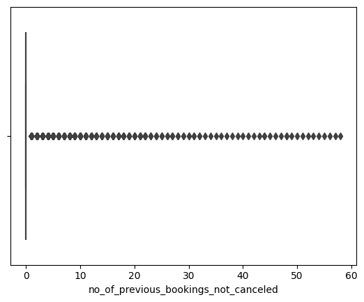

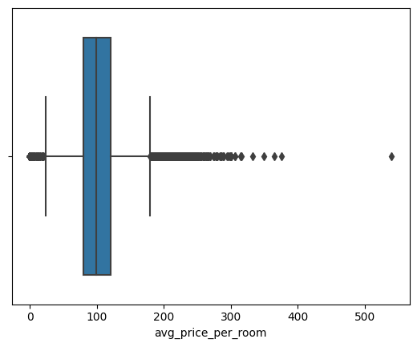

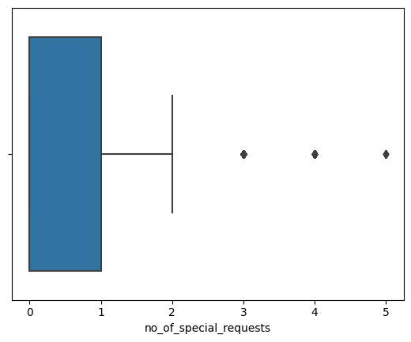

```python
df_numeric_cols = df.select_dtypes(include = np.number)
for i in df_numeric_cols:
  sns.boxplot(data = df_numeric_cols, x = i)
  plt.show()
```

When we create boxplots of all the numerical variables within the dataset, it only makes sense to control outliers for lead time and the average room price. This is because the other variables have a small enough range to where they become 'pseudocategories' and every value or nearly every value becomes an outlier.

```python
Q1 = df["avg_price_per_room"].quantile(0.25)
Q3 = df["avg_price_per_room"].quantile(0.75)
IQR = Q3 - Q1
low_end = Q1 - (1.5 * IQR)
high_end = Q3 + (1.5 * IQR)

df["avg_price_per_room"] = np.clip(df["avg_price_per_room"], low_end, high_end)
```

```python
Q1 = df["lead_time"].quantile(0.25)
Q3 = df["lead_time"].quantile(0.75)
IQR = Q3 - Q1
low_end = Q1 - (1.5 * IQR)
high_end = Q3 + (1.5 * IQR)

df["lead_time"] = np.clip(df["lead_time"], low_end, high_end)
```

## EDA

- It is a good idea to explore the data once again after manipulating it.

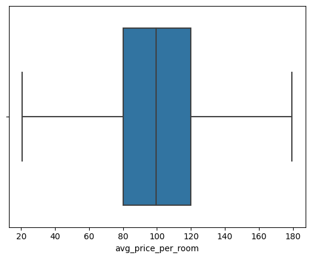

```python
sns.boxplot(data = df, x = "avg_price_per_room")
```

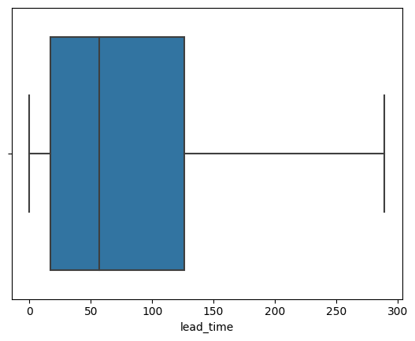

```python
sns.boxplot(data = df, x = "lead_time")
```

These are the boxplots we get when we control outliers for lead time and average room price.

## Checking Multicollinearity

- In order to make statistical inferences from a logistic regression model, it is important to ensure that there is no multicollinearity present in the data.

```python
bookingDummies = pd.get_dummies(df["booking_status"], drop_first = True)
```

```python
X = df.drop(["booking_status"], axis=1)
Y = bookingDummies

X = sm.add_constant(X)

X = pd.get_dummies(X, drop_first = True)
X_train, X_test, Y_train, Y_test = train_test_split(X, Y, train_size = 0.10, random_state = 1)
X_train.info()
Y.shape
```

```
<class 'pandas.core.frame.DataFrame'>
Int64Index: 3627 entries, 3220 to 33003
Data columns (total 25 columns):
 #   Column                                Non-Null Count  Dtype
---  ------                                --------------  -----
 0   const                                 3627 non-null   float64
 1   no_of_adults                          3627 non-null   int64
 2   no_of_children                        3627 non-null   int64
 3   no_of_weekend_nights                  3627 non-null   int64
 4   no_of_week_nights                     3627 non-null   int64
 5   required_car_parking_space            3627 non-null   int64
 6   lead_time                             3627 non-null   float64
 7   repeated_guest                        3627 non-null   int64
 8   no_of_previous_cancellations          3627 non-null   int64
 9   no_of_previous_bookings_not_canceled  3627 non-null   int64
```

[output cut: 17 more lines]

```
(36275, 1)
```

```python
vif = pd.Series([variance_inflation_factor(X_train.values, i) for i in range(len(X_train.columns))], index = X_train.columns, dtype = float)
print(vif)
```

```
const                                   624.920081
no_of_adults                              1.322935
no_of_children                            1.949981
no_of_weekend_nights                      1.066055
no_of_week_nights                         1.106246
required_car_parking_space                1.035157
lead_time                                 1.256991
repeated_guest                            1.731119
no_of_previous_cancellations              1.373274
no_of_previous_bookings_not_canceled      1.534240
avg_price_per_room                        1.894560
no_of_special_requests                    1.240809
type_of_meal_plan_Meal Plan 2             1.226272
type_of_meal_plan_Meal Plan 3             1.066307
type_of_meal_plan_Not Selected            1.249726
room_type_reserved_Room_Type 2            1.116585
room_type_reserved_Room_Type 3            1.015154
room_type_reserved_Room_Type 4            1.375438
room_type_reserved_Room_Type 5            1.025736
room_type_reserved_Room_Type 6            1.882573
room_type_reserved_Room_Type 7            1.133928
market_segment_type_Complementary         8.956076
market_segment_type_Corporate            30.556867
market_segment_type_Offline             126.277289
market_segment_type_Online              140.406499
dtype: float64
```

When we check for multicollinearity using the variance inflation factor as a measure, we get high VIFs for market segment type, especially between Online and Offline market types. This makes sense because Online and Offline are the inverse of each other. Therefore one can explain the other with no error.

```python
newX_train1 = X_train.drop(["market_segment_type_Online"], axis = 1)
vif2 = pd.Series([variance_inflation_factor(newX_train1.values, i) for i in range(len(newX_train1.columns))], index = newX_train1.columns, dtype = float)
print(vif2)
```

```
const                                   39.322358
no_of_adults                             1.313587
no_of_children                           1.949688
no_of_weekend_nights                     1.065714
no_of_week_nights                        1.100625
required_car_parking_space               1.035146
lead_time                                1.262140
repeated_guest                           1.730858
no_of_previous_cancellations             1.373273
no_of_previous_bookings_not_canceled     1.534210
avg_price_per_room                       1.894561
no_of_special_requests                   1.238373
type_of_meal_plan_Meal Plan 2            1.237847
type_of_meal_plan_Meal Plan 3            1.066306
type_of_meal_plan_Not Selected           1.248611
room_type_reserved_Room_Type 2           1.116214
room_type_reserved_Room_Type 3           1.015145
room_type_reserved_Room_Type 4           1.369798
room_type_reserved_Room_Type 5           1.025729
room_type_reserved_Room_Type 6           1.882348
room_type_reserved_Room_Type 7           1.133804
market_segment_type_Complementary        1.391291
market_segment_type_Corporate            1.502516
market_segment_type_Offline              1.626052
dtype: float64
```

When the column with the highest VIF is dropped (Online Market Segment Type), we get much lower VIFs for everything else. We can now use this dataframe for further model building.

## Building a Logistic Regression model

```python
logit2 = sm.Logit(Y_train, newX_train1.astype(float))
lg2 = logit2.fit(disp = False)
print(lg2.summary())
```

```
                           Logit Regression Results
==============================================================================
Dep. Variable:           Not_Canceled   No. Observations:                 3627
Model:                          Logit   Df Residuals:                     3603
Method:                           MLE   Df Model:                           23
Date:                Sat, 16 Dec 2023   Pseudo R-squ.:                     inf
Time:                        02:06:11   Log-Likelihood:                   -inf
converged:                      False   LL-Null:                        0.0000
Covariance Type:            nonrobust   LLR p-value:                     1.000
========================================================================================================
                                           coef    std err          z      P>|z|      [0.025      0.975]
--------------------------------------------------------------------------------------------------------
const                                    3.2372      0.291     11.141      0.000       2.668       3.807
no_of_adults                            -0.0578      0.098     -0.589      0.556      -0.250       0.135
no_of_children                          -0.3164      0.134     -2.357      0.018      -0.580      -0.053
no_of_weekend_nights                    -0.1152      0.052     -2.214      0.027      -0.217      -0.013
no_of_week_nights                       -0.0590      0.034     -1.731      0.084      -0.126       0.008
required_car_parking_space               1.3710      0.329      4.162      0.000       0.725       2.017
lead_time                               -0.0157      0.001    -23.751      0.000      -0.017      -0.014
repeated_guest                           1.5851      0.861      1.841      0.066      -0.103       3.273
no_of_previous_cancellations            -0.2446      0.143     -1.709      0.087      -0.525       0.036
no_of_previous_bookings_not_canceled     0.0691      0.147      0.470      0.638      -0.219       0.357
avg_price_per_room                      -0.0209      0.002    -10.545      0.000      -0.025      -0.017
no_of_special_requests                   1.4660      0.078     18.737      0.000       1.313       1.619
type_of_meal_plan_Meal Plan 2           -0.0380      0.171     -0.223      0.824      -0.373       0.296
type_of_meal_plan_Meal Plan 3           -1.8979   1.28e+05  -1.48e-05      1.000   -2.51e+05    2.51e+05
type_of_meal_plan_Not Selected          -0.2412      0.137     -1.764      0.078      -0.509       0.027
room_type_reserved_Room_Type 2           0.7281      0.324      2.244      0.025       0.092       1.364
room_type_reserved_Room_Type 3          17.9704   2.82e+04      0.001      0.999   -5.53e+04    5.53e+04
room_type_reserved_Room_Type 4           0.3416      0.138      2.474      0.013       0.071       0.612
room_type_reserved_Room_Type 5           0.6052      0.668      0.906      0.365      -0.704       1.914
room_type_reserved_Room_Type 6           1.2933      0.358      3.608      0.000       0.591       1.996
room_type_reserved_Room_Type 7           0.5653      0.580      0.975      0.330      -0.571       1.701
market_segment_type_Complementary       21.1510   2.08e+04      0.001      0.999   -4.07e+04    4.08e+04
market_segment_type_Corporate            0.6345      0.260      2.442      0.015       0.125       1.144
market_segment_type_Offline              1.9714      0.141     13.962      0.000       1.695       2.248
========================================================================================================
```

## Model performance evaluation

```python
newX_test1 = X_test[list(newX_train1.columns)]
```

```python
def performance_measures(model, x, y, thresh):
  predictions = model.predict(x) > thresh
  accuracy = accuracy_score(y, predictions)
  recall = recall_score(y, predictions)
  precision = precision_score(y, predictions)
  f1Score = f1_score(y, predictions)
  performance = {"Accuracy": [accuracy], "Recall": [recall], "Precision": [precision], "F1 Score": [f1Score]}
  performance = pd.DataFrame(performance)
  performance.index = ["Performance Measures"]
  return performance
```

```python
performance_measures(lg2, newX_train1, Y_train, 0.5)
```

|  | Accuracy | Recall | Precision | F1 Score |
| --- | --- | --- | --- | --- |
| Performance Measures | 0.801765 | 0.893184 | 0.823056 | 0.856687 |

```python
performance_measures(lg2, newX_test1, Y_test, 0.5)
```

|  | Accuracy | Recall | Precision | F1 Score |
| --- | --- | --- | --- | --- |
| Performance Measures | 0.802224 | 0.886053 | 0.831335 | 0.857822 |

First model and evaluation above.

```python
columns = newX_train1.columns

max_pvalue = max(lg2.pvalues)

for i in columns:
  if lg2.pvalues[i] > 0.05:
    newX_train1 = newX_train1.drop([i], axis = 1)



newX_train2 = X_train[list(newX_train1.columns)]
newX_train2.columns
```

```
Index(['const', 'no_of_children', 'no_of_weekend_nights',
       'required_car_parking_space', 'lead_time', 'avg_price_per_room',
       'no_of_special_requests', 'room_type_reserved_Room_Type 2',
       'room_type_reserved_Room_Type 4', 'room_type_reserved_Room_Type 6',
       'market_segment_type_Corporate', 'market_segment_type_Offline'],
      dtype='object')
```

```python
newX_test2 = X_test[list(newX_train2.columns)]
```

Removing coefficients with a P Value greater than 0.05, representing a lack of statistical significance regarding the features effect on the the probability of a positive prediction

## Final Model Summary

```python
logit3 = sm.Logit(Y_train, newX_train2.astype(float))
lg3 = logit3.fit(disp = False)
print(lg3.summary())
```

```
                           Logit Regression Results
==============================================================================
Dep. Variable:           Not_Canceled   No. Observations:                 3627
Model:                          Logit   Df Residuals:                     3615
Method:                           MLE   Df Model:                           11
Date:                Sat, 16 Dec 2023   Pseudo R-squ.:                     inf
Time:                        02:06:26   Log-Likelihood:                   -inf
converged:                       True   LL-Null:                        0.0000
Covariance Type:            nonrobust   LLR p-value:                     1.000
==================================================================================================
                                     coef    std err          z      P>|z|      [0.025      0.975]
--------------------------------------------------------------------------------------------------
const                              2.9261      0.210     13.945      0.000       2.515       3.337
no_of_children                    -0.2760      0.132     -2.096      0.036      -0.534      -0.018
no_of_weekend_nights              -0.1215      0.051     -2.371      0.018      -0.222      -0.021
required_car_parking_space         1.3754      0.328      4.197      0.000       0.733       2.018
lead_time                         -0.0159      0.001    -24.776      0.000      -0.017      -0.015
avg_price_per_room                -0.0205      0.002    -11.416      0.000      -0.024      -0.017
no_of_special_requests             1.4562      0.077     18.814      0.000       1.305       1.608
room_type_reserved_Room_Type 2     0.7713      0.321      2.405      0.016       0.143       1.400
room_type_reserved_Room_Type 4     0.3539      0.130      2.728      0.006       0.100       0.608
room_type_reserved_Room_Type 6     1.2288      0.347      3.544      0.000       0.549       1.908
market_segment_type_Corporate      0.9391      0.243      3.860      0.000       0.462       1.416
market_segment_type_Offline        2.0445      0.130     15.745      0.000       1.790       2.299
==================================================================================================
```

```python
'''
threshold = 0.5
predictions = lg3.predict(newX_train) > threshold
accuracy = accuracy_score(Y_train, predictions)
recall = recall_score(Y_train, predictions)
precision = precision_score(Y_train, predictions)
print(accuracy, recall, precision)
'''

performance_measures(lg3, newX_train2, Y_train, 0.5)
```

|  | Accuracy | Recall | Precision | F1 Score |
| --- | --- | --- | --- | --- |
| Performance Measures | 0.797077 | 0.888196 | 0.820661 | 0.853094 |

```python
performance_measures(lg3, newX_test2, Y_test, 0.5)
```

|  | Accuracy | Recall | Precision | F1 Score |
| --- | --- | --- | --- | --- |
| Performance Measures | 0.798303 | 0.883825 | 0.828183 | 0.8551 |

```
Area Under The Curve: 0.8555617508235962
```

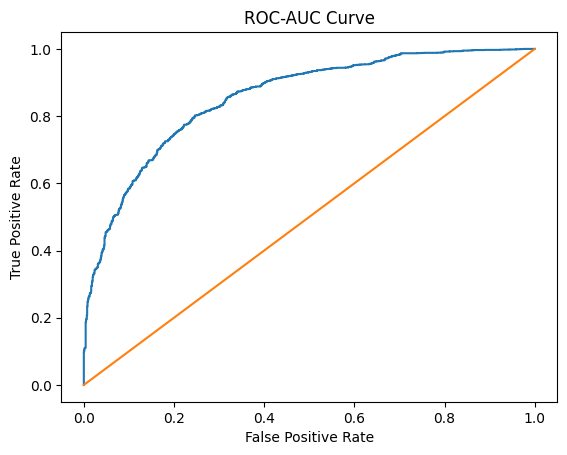

```python
logit_roc_auc_train = roc_auc_score(Y_train, lg3.predict(newX_train2))
print("Area Under The Curve: " + str(logit_roc_auc_train))
falsePos, truePos, thresholds = roc_curve(Y_train, lg3.predict(newX_train2))
plt.plot(falsePos, truePos)
plt.xlabel("False Positive Rate")
plt.ylabel("True Positive Rate")
plt.title("ROC-AUC Curve")
plt.plot([0,1],[0,1])
plt.show()
```

```python
diffArray = truePos - falsePos
index_of_highest = np.argmax(diffArray)
optThreshold = thresholds[index_of_highest]
```

```python
threshold = optThreshold
'''
predictions = lg3.predict(newX_train) > threshold
accuracy = accuracy_score(Y_train, predictions)
recall = recall_score(Y_train, predictions)
precision = precision_score(Y_train, predictions)
print(accuracy, recall, precision)
'''
performance_measures(lg3, newX_train2, Y_train, threshold)
```

|  | Accuracy | Recall | Precision | F1 Score |
| --- | --- | --- | --- | --- |
| Performance Measures | 0.784395 | 0.800083 | 0.86478 | 0.831174 |

```python
performance_measures(lg3, newX_test2, Y_test, threshold)
```

|  | Accuracy | Recall | Precision | F1 Score |
| --- | --- | --- | --- | --- |
| Performance Measures | 0.780538 | 0.791712 | 0.870642 | 0.829303 |

```
WARNING:matplotlib.legend:No artists with labels found to put in legend.  Note that artists whose label start with an underscore are ignored when legend() is called with no argument.
```

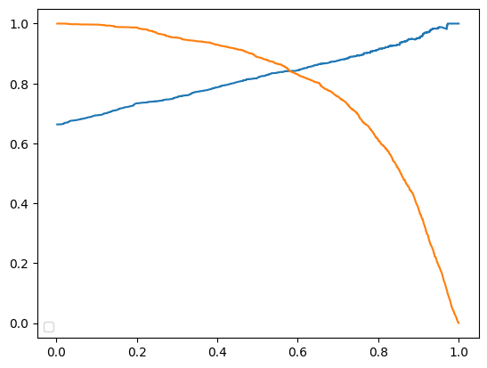

```python
predictions = lg3.predict(newX_train2)
prec, rec, threshold = precision_recall_curve(Y_train, predictions)
plt.plot(threshold, prec[:-1])
plt.plot(threshold, rec[:-1])
plt.legend(loc = "lower left")
```

Above are models built from changing the threshold of positive prediction. The first method is using the ROC-AUC Curve and the second method is using the point where precision meets recall on a precision recall curve.

```python
threshold = 0.58
'''
predictions = lg3.predict(newX_train) > threshold
accuracy = accuracy_score(Y_train, predictions)
recall = recall_score(Y_train, predictions)
precision = precision_score(Y_train, predictions)
print(accuracy, recall, precision)
'''
performance_measures(lg3, newX_train2, Y_train, threshold)
```

|  | Accuracy | Recall | Precision | F1 Score |
| --- | --- | --- | --- | --- |
| Performance Measures | 0.789358 | 0.840815 | 0.841514 | 0.841164 |

```python
performance_measures(lg3, newX_test2, Y_test, threshold)
```

|  | Accuracy | Recall | Precision | F1 Score |
| --- | --- | --- | --- | --- |
| Performance Measures | 0.792514 | 0.837609 | 0.85179 | 0.84464 |

```python
odds = np.exp(lg3.params)


perc_change_odds = (np.exp(lg3.params) - 1) * 100

pd.set_option("display.max_columns", None)


pd.DataFrame({"Odds": odds, "Change_odd%": perc_change_odds}, index=newX_train2.columns).T
```

|  | const | no_of_children | no_of_weekend_nights | required_car_parking_space | lead_time | avg_price_per_room | no_of_special_requests | room_type_reserved_Room_Type 2 | room_type_reserved_Room_Type 4 | room_type_reserved_Room_Type 6 | market_segment_type_Corporate | market_segment_type_Offline |
| --- | --- | --- | --- | --- | --- | --- | --- | --- | --- | --- | --- | --- |
| Odds | 18.655512 | 0.758825 | 0.885578 | 3.956642 | 0.984206 | 0.979749 | 4.289663 | 2.162634 | 1.424634 | 3.417197 | 2.557697 | 7.724918 |
| Change_odd% | 1765.551205 | -24.117492 | -11.442186 | 295.664225 | -1.579385 | -2.025090 | 328.966254 | 116.263411 | 42.463376 | 241.719747 | 155.769668 | 672.491785 |

## Building a Decision Tree model

```python
DTModel = DecisionTreeClassifier(random_state = 1)
DTModel = DTModel.fit(X_train, Y_train)
```

```python
def performance_measures_no_thresh(model, x, y):
  predictions = model.predict(x)
  accuracy = accuracy_score(y, predictions)
  recall = recall_score(y, predictions)
  precision = precision_score(y, predictions)
  f1Score = f1_score(y, predictions)
  performance = {"Accuracy": [accuracy], "Recall": [recall], "Precision": [precision], "F1 Score": [f1Score]}
  performance = pd.DataFrame(performance)
  performance.index = ["Performance Measures"]
  return performance
```

```python
performance_measures_no_thresh(DTModel, X_train, Y_train)
```

|  | Accuracy | Recall | Precision | F1 Score |
| --- | --- | --- | --- | --- |
| Performance Measures | 0.996691 | 0.995844 | 0.999166 | 0.997502 |

```python
performance_measures_no_thresh(DTModel, X_test, Y_test)
```

|  | Accuracy | Recall | Precision | F1 Score |
| --- | --- | --- | --- | --- |
| Performance Measures | 0.806665 | 0.836699 | 0.871093 | 0.85355 |

```python
DTModelRW = DecisionTreeClassifier(random_state = 1, class_weight = "balanced")
DTModelRW = DTModel.fit(X_train, Y_train)
```

```python
performance_measures_no_thresh(DTModelRW, X_train, Y_train)
```

|  | Accuracy | Recall | Precision | F1 Score |
| --- | --- | --- | --- | --- |
| Performance Measures | 0.996691 | 0.995844 | 0.999166 | 0.997502 |

```python
performance_measures_no_thresh(DTModelRW, X_test, Y_test)
```

|  | Accuracy | Recall | Precision | F1 Score |
| --- | --- | --- | --- | --- |
| Performance Measures | 0.806665 | 0.836699 | 0.871093 | 0.85355 |

## Do we need to prune the tree?

```python
estimator = DecisionTreeClassifier(random_state = 1)

parGrid = {
    "class_weight" : [None, "balanced"],
    "max_depth" : [2, 4, 6],
    "max_leaf_nodes" : [10, 20, 30],
    "min_samples_split" : [30, 40, 50, 60]
}

scorer = make_scorer(recall_score)

gridObject = GridSearchCV(estimator, parGrid, scoring = scorer, cv = 3)
gridObject = gridObject.fit(X_train, Y_train)

bestEst = gridObject.best_estimator_

bestEst.fit(X_train, Y_train)
```

```
DecisionTreeClassifier(max_depth=2, max_leaf_nodes=10, min_samples_split=30,
                       random_state=1)
```

Above is the pre pruning method using a grid search cross validation method to test different parameter combinations to create best pruned model that can work for both the training and test sets. The scoring measure used here is recall

```python
performance_measures_no_thresh(bestEst, X_train, Y_train)
```

|  | Accuracy | Recall | Precision | F1 Score |
| --- | --- | --- | --- | --- |
| Performance Measures | 0.755997 | 0.916874 | 0.763058 | 0.832924 |

```python
performance_measures_no_thresh(bestEst, X_test, Y_test)
```

|  | Accuracy | Recall | Precision | F1 Score |
| --- | --- | --- | --- | --- |
| Performance Measures | 0.760782 | 0.919078 | 0.770125 | 0.838034 |

After the pruning, the recall is about .92 for both the training and test data sets.

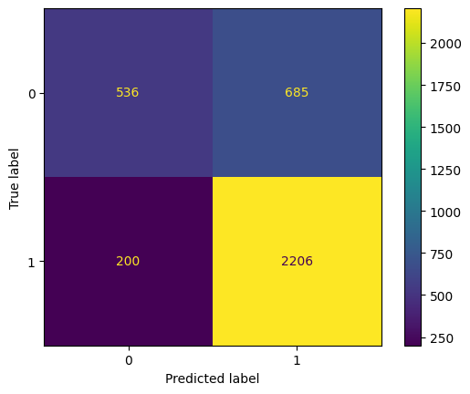

```python
cm = confusion_matrix(Y_train, bestEst.predict(X_train))
cmDisplay = ConfusionMatrixDisplay(confusion_matrix = cm)

cmDisplay.plot()
plt.show()
```

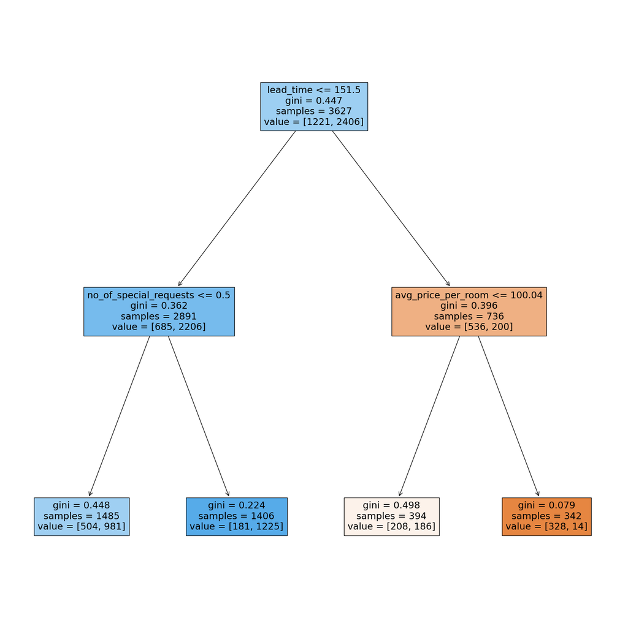

```python
plt.figure(figsize = (20,20))
tree_plot = tree.plot_tree(bestEst, feature_names = X_train.columns, filled = True)


plt.show()
```